# Modelling spatial spread I - Exercises

Andrea Parisi

## **Exercise 1**

*Increase the number of patches and observe how the infection curves will tend to overlap when such number becomes large. Can you explain why?*

We start from 16 patches, and we increase the number to 50, 300, 1000.

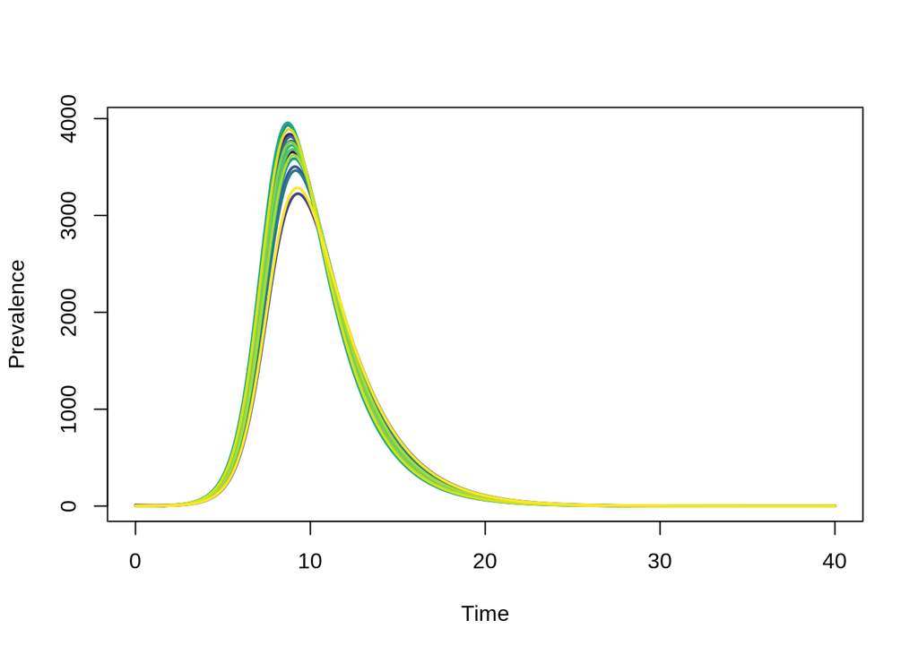

```r
patches <- 16
NN <- rep(10000, patches)

rho <- randomContactMatrix(patches)

start.I0 <- rep(0, patches)
start.I0[1] <- 10
start.S0 <- NN-start.I0
xstart <- c( start.S0, start.I0 )
params <- list(patches, mu, gamma, beta, rho, NN)

res <- deSolve::ode( xstart, times, sir.model, params, method=deSolve::rk4 )

output <- data.frame( res )
showOutput(output, patches, NN)
```

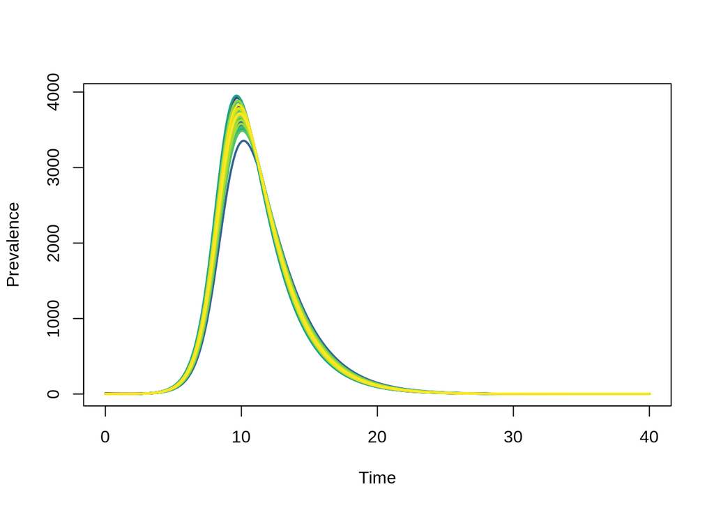

```r
patches <- 50
NN <- rep(10000, patches)

rho <- randomContactMatrix(patches)

start.I0 <- rep(0, patches)
start.I0[1] <- 10
start.S0 <- NN-start.I0
xstart <- c( start.S0, start.I0 )
params <- list(patches, mu, gamma, beta, rho, NN)

res <- deSolve::ode( xstart, times, sir.model, params, method=deSolve::rk4 )

output <- data.frame( res )
showOutput(output, patches, NN)
```

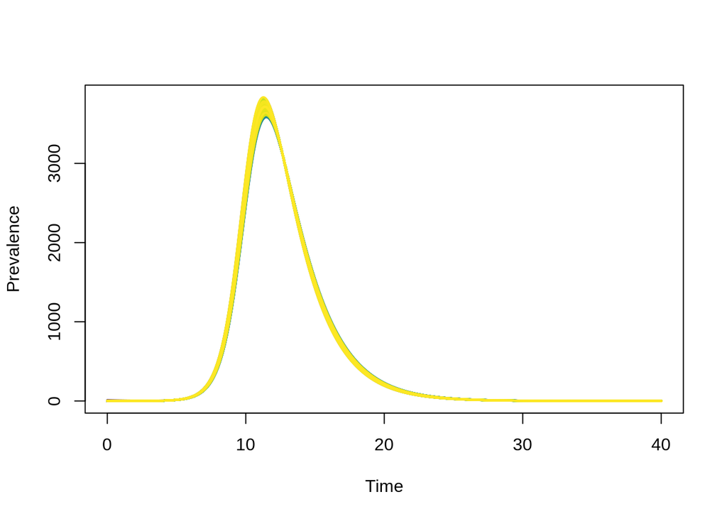

```r
patches <- 300
NN <- rep(10000, patches)

rho <- randomContactMatrix(patches)

start.I0 <- rep(0, patches)
start.I0[1] <- 10
start.S0 <- NN-start.I0
xstart <- c( start.S0, start.I0 )
params <- list(patches, mu, gamma, beta, rho, NN)

res <- deSolve::ode( xstart, times, sir.model, params, method=deSolve::rk4 )

output <- data.frame( res )
showOutput(output, patches, NN)
```

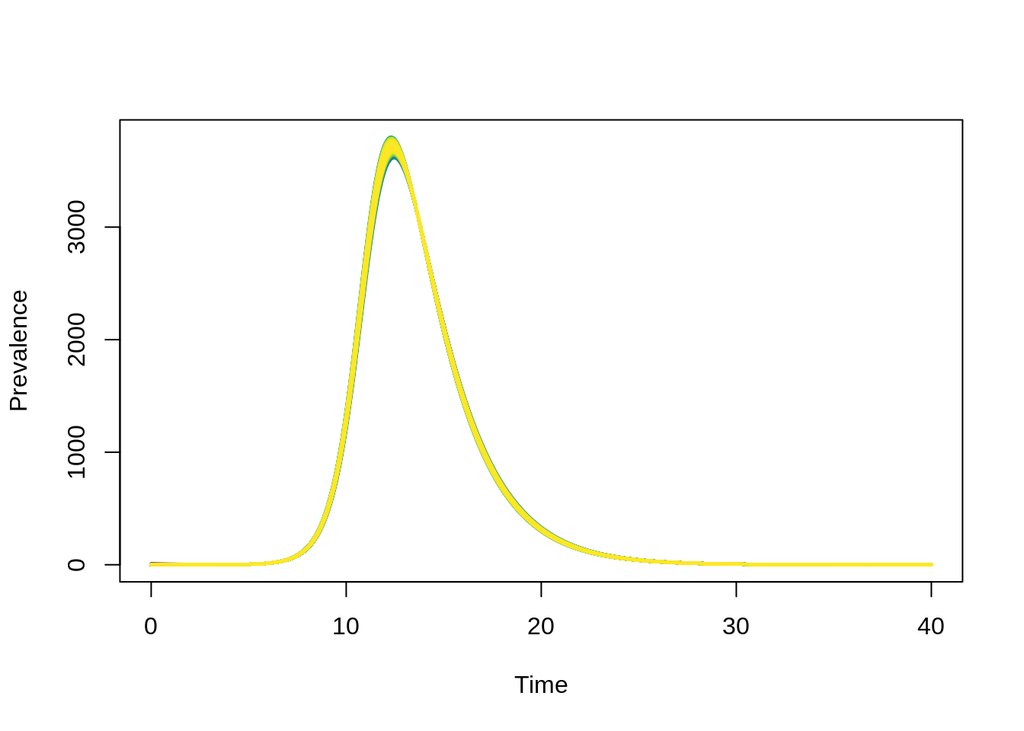

```r
patches <- 1000
NN <- rep(10000, patches)

rho <- randomContactMatrix(patches)

start.I0 <- rep(0, patches)
start.I0[1] <- 10
start.S0 <- NN-start.I0
xstart <- c( start.S0, start.I0 )
params <- list(patches, mu, gamma, beta, rho, NN)

res <- deSolve::ode( xstart, times, sir.model, params, method=deSolve::rk4 )

output <- data.frame( res )
showOutput(output, patches, NN)
```

EACH patch will average out difference between influx from other patches: as the number of patches increases, all patches will see their influx converge towards a common average value.

# **Exercise 2**

*Increase or decrease the population size and the initial number of infectives of each patch by the same amount. What happens to the infection curves? Why?*

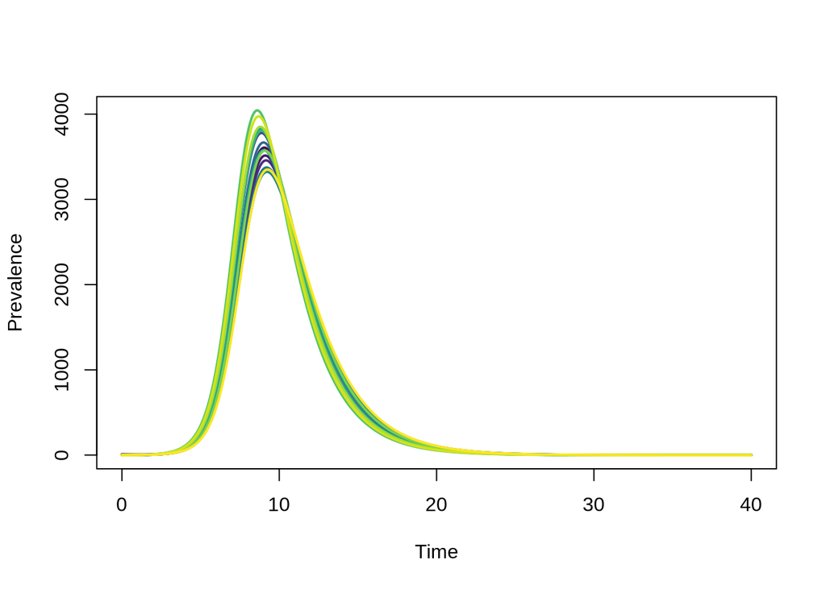

```r
side <- 4
patches <- 16
NN <- rep(10000, patches)

rho <- randomContactMatrix(patches)

start.I0 <- rep(0, patches)
start.I0[1] <- 10
start.S0 <- NN-start.I0
xstart <- c( start.S0, start.I0 )
params <- list(patches, mu, gamma, beta, rho, NN)

res <- deSolve::ode( xstart, times, sir.model, params, method=deSolve::rk4 )

output <- data.frame( res )
showOutput(output, patches, NN)
```

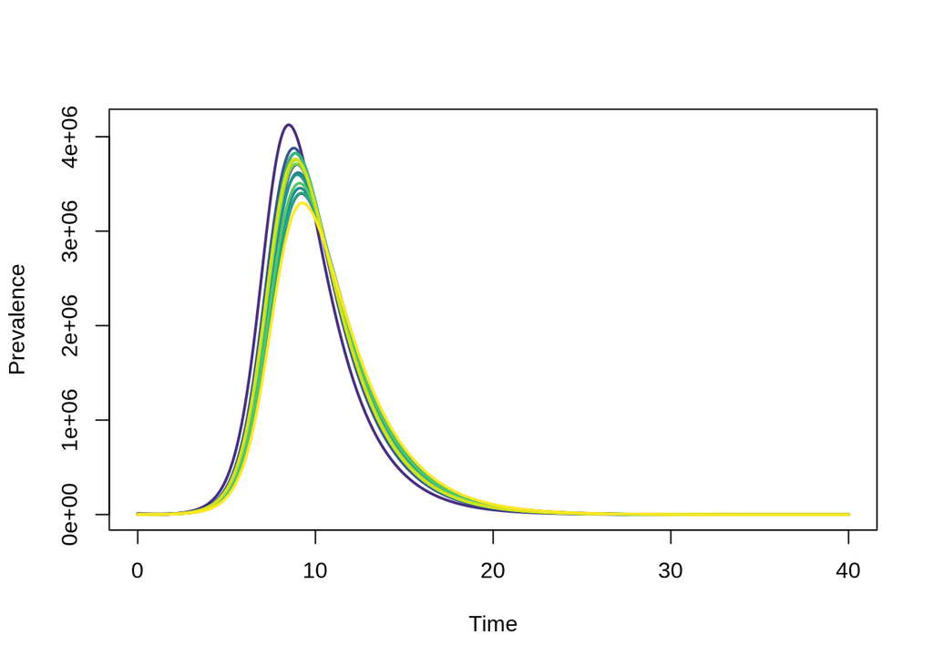

```r
patches <- 16
NN <- rep(10000000, patches)

rho <- randomContactMatrix(patches)

start.I0 <- rep(0, patches)
start.I0[1] <- 10000
start.S0 <- NN-start.I0
xstart <- c( start.S0, start.I0 )
params <- list(patches, mu, gamma, beta, rho, NN)

res <- deSolve::ode( xstart, times, sir.model, params, method=deSolve::rk4 )

output <- data.frame( res )
showOutput(output, patches, NN)
```

Modifying the population size does not have any effect since these are continuous model and the contact matrix represents population fractions.

## **Exercise 3**

This is the original nearest-neighbours matrix

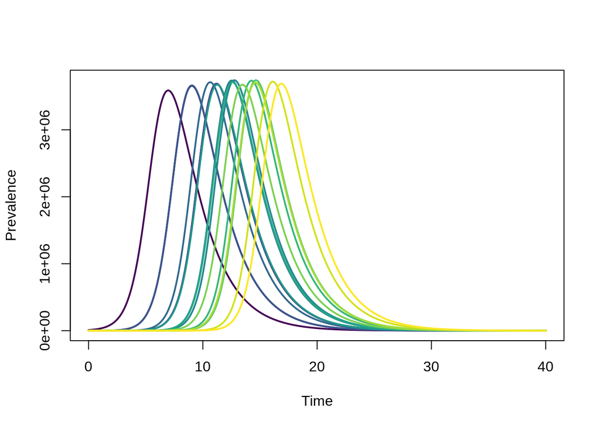

```r
entry <- 1
rho <- zeros(patches) # Generates a matrix of zeros
for (dst in 1:patches)  {
    for (src in 1:patches)  {
        if (dst == src)  {
            rho[dst,src] <- 0.96 # 1 - 4*0.01 - 4*0.05
        } else if (dst == src+side || dst == src-side ||
                   dst == src+1 || dst == src-1)  {
            rho[dst,src] <- 0.01
        }
    }
}
params <- list(patches, mu, gamma, beta, rho, NN)

res <- deSolve::ode( xstart, times, sir.model, params, method=deSolve::rk4 )

output <- data.frame( res )
showOutput(output, patches, NN)
```

This is a contact matrix with additional tranmission to second nearest neighbours

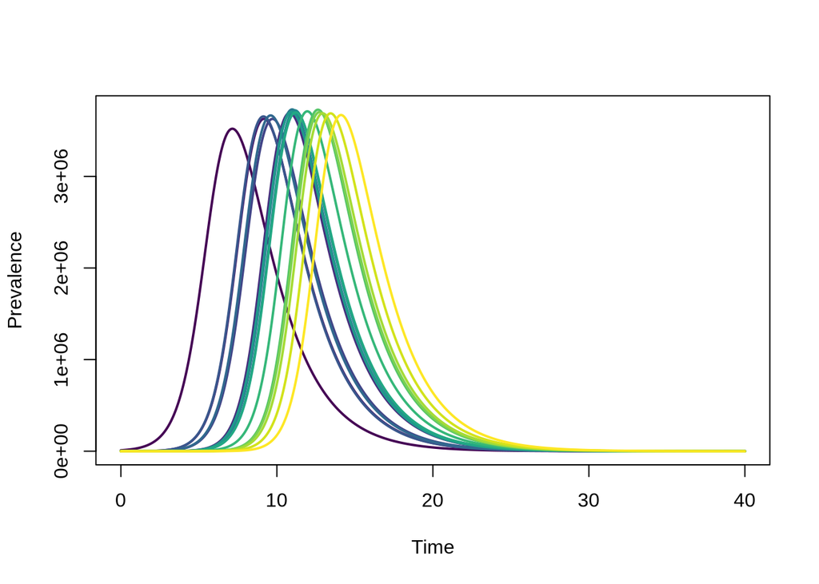

```r
entry <- 1
rho <- zeros(patches) # Generates a patches x patches matrix of zeros
for (dst in 1:patches)  {
    for (src in 1:patches)  {
        if (dst == src)  {
            rho[dst,src] <- 0.94 # 1 - 4*0.01 - 4*0.05
        } else if (dst == src+side || dst == src-side ||
                   dst == src+1 || dst == src-1)  {
            rho[dst,src] <- 0.01
        } else if (dst == src+side-1 || dst == src-side-1 ||
                   dst == src+side+1 || dst == src-side+1)  {
            rho[dst,src] <- 0.005
        }
    }
}
params <- list(patches, mu, gamma, beta, rho, NN)

res <- deSolve::ode( xstart, times, sir.model, params, method=deSolve::rk4 )

output <- data.frame( res )
showOutput(output, patches, NN)
```

Increasing the coupling between counties makes outbreaks in far countries occur earlier.

## **Exercise 4**

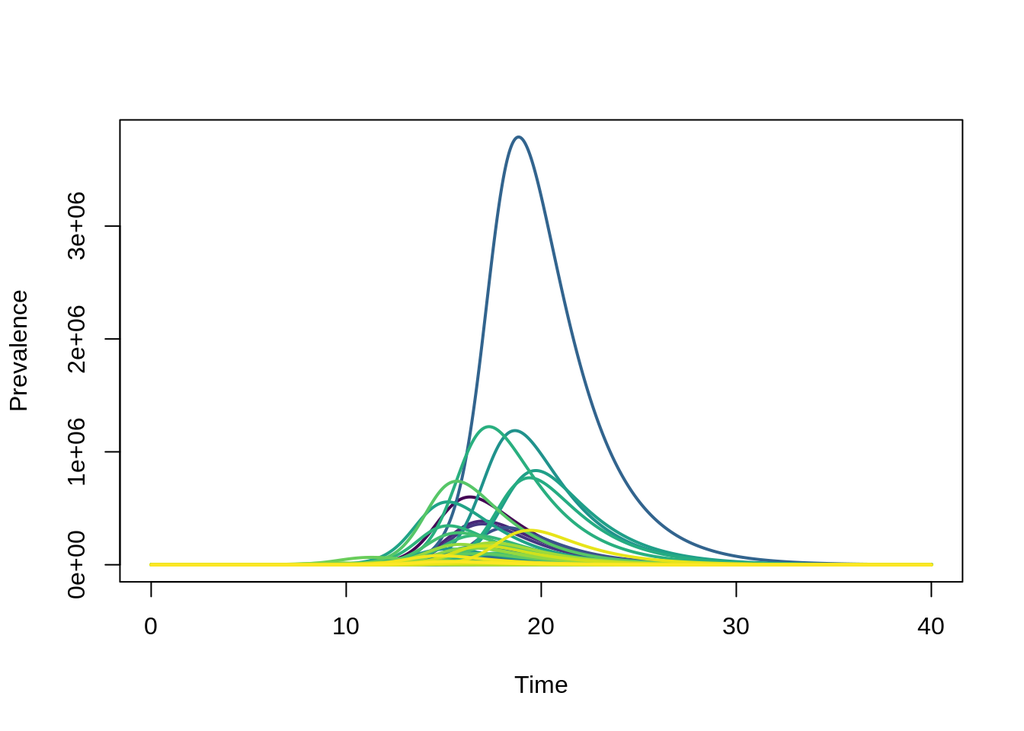

```r
NN <- counties.wsg84$pop
beta <- 1.66
times <- seq( from = 0, to = 40, by = 0.05)

rho <- build.contact.matrix( counties.wsg84, comm, "Total" )
patches <- nrow(rho)

# Find counties 'Modoc' and 'Los Angeles'
modoc <- which(counties.wsg84$NAME == "Modoc")
start.I0 <- rep(0, patches)
start.I0[modoc] <- 10
start.S0 <- NN-start.I0
xstart <- c( start.S0, start.I0 )
params <- list(patches, mu, gamma, beta, rho, NN)

res <- deSolve::ode( xstart, times, sir.model, params, method=deSolve::rk4 )

output <- data.frame( res )
showOutput(output, patches, NN)
```

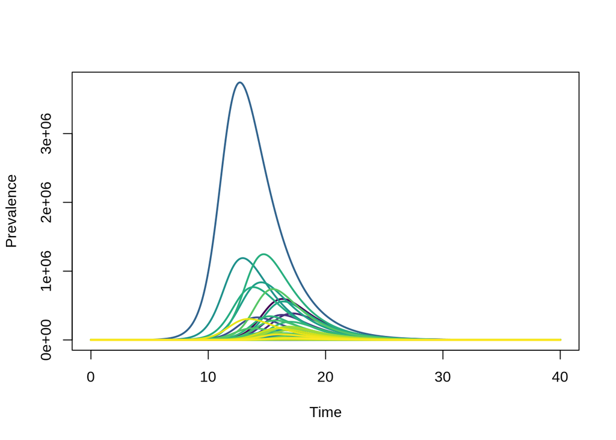

```r
losangeles <- which(counties.wsg84$NAME == "Los Angeles")
start.I0 <- rep(0, patches)
start.I0[losangeles] <- 10
start.S0 <- NN-start.I0
xstart <- c( start.S0, start.I0 )
params <- list(patches, mu, gamma, beta, rho, NN)

res <- deSolve::ode( xstart, times, sir.model, params, method=deSolve::rk4 )

output <- data.frame( res )
showOutput(output, patches, NN)
```

Los Angeles has higher connections than the Modoc county, thus an initial infective in Los Angeles would cause a faster epidemic throughout California.